# Performa Cabang

Alfazrin Banapon

August 19, 2020

### Latar Belakang

DQLab Finance merupakan perusahaan finance yang sudah mempunyai banyak cabang tersebar dimana-mana. Sejak berdiri pada Januari 2020, DQLab Finance konsisten menyalurkan pembiayaan untuk masyarakat dan semakin berkembang setiap bulannya dengan membuka cabang baru.

Walaupun berumur kurang dari 1 tahun, DQLab Finance sudah mempunyai banyak cabang, oleh karena itu perlu dipantau bagaimana performa dari cabang - cabang tersebut.

Pada masing-masing cabang, terdapat agen-agen yang bertugas mencari dan mendata calon mitra yang akan mengajukan pinjaman kepada DQLab Finance. Lalu jika sudah disetujui, agen juga yang akan memberikan uang tersebut kepada mitra.

### Tugas dan langkah

Sebagai seorang data analyst, kamu diminta untuk menganalisis performa dari cabang-cabang yang ada di DQLab Finance.

Pada tugas kali ini, kamu akan menganalisis bagaimana performa cabang pada bulan lalu, yakni Mei 2020.

Langkah yang akan dilakukan adalah,

Memfilter data untuk bulan Mei 2020 Membuat summary per cabang untuk melihat data 5 cabang terbaik dan terburuk Karena cabang bertambah setiap bulannya, maka perlu dicek umur cabang dan performa mei Mencari cabang terburuk untuk masing - masing kelompok umur

### Library yang digunakan

Pada analisis kali ini, akan digunakan beberapa package yang membantu kita dalam melakukan analisis data,

1. Package `dplyr`, merupakan package yang paling sering digunakan dalam analisis data, sangat membantu dalam manipulasi data, fungsi yang paling sering digunakan adalah :
- `mutate()` membuat variabel baru berdasarkan variabel yang ada
- `select()` memilih variabel berdasarkan namannya
- `filter()` memfilter data berdasarkan value dari variabel
- `summarise()` mengubah beberapa nilai menjadi satu ringkasan nilai
- `arrange()` mengurutkan baris data
2. Package `ggplot2`, merupakan package yang digunakan untuk membuat plot dengan syntax yang konsisten, secara umum, untuk membuat plot dengan memanggil fungsi,

`ggplot(data) + geom_type(aes(x,y,fill,color))`

**geom_type** diganti dengan fungsi sesuai dengan jenis plot yang diharapkan, misalnya **geom_line, geom_bar, geom_point, geom_boxplot** dan lainnya.

3. Packages `scales`, digunakan untuk memformat value data numerik menjadi format yang mudah dibaca, tidak terlalu sering digunakan, tapi membantu ketika eksplorasi data. fungsi yang biasa dipakai adalah :
- `comma()` mengubah numerik menjadi ada simbol ribuan, misalnya 10000000000 diubah menjadi 10,000,000,000
- `percent()` mengubah numerik menjadi ada format persen, misalnya 0.65877 diubah menjadi 66%

### Data yang digunakan

`df_loan <- read.csv('https://dqlab-dataset.s3-ap-southeast-1.amazonaws.com/loan_disbursement.csv', stringsAsFactors = F)`

`stringsAsFactors` ini berguna agar data-data yang bertipe character (seperti nama cabang, agen dan tanggal) tidak diubah menjadi factor.

untuk melihat datanya, gunakan fungsi `glimpse` dari package dplyr. karena hanya pakai 1 fungsi, kita bisa memanggilnya tanpa load package nya, yakni dengan menggunakan symbol :: dan format package::fungsi()

`dplyr::glimpse(df_loan)`

silahkan jalankan 2 fungsi tersebut untuk membaca dan melihat isi datanya.

```r
df_loan <- read.csv('https://dqlab-dataset.s3-ap-southeast-1.amazonaws.com/loan_disbursement.csv', stringsAsFactors = F)
dplyr::glimpse(df_loan)
```

```
## Observations: 9,754
## Variables: 5
## $ loan_id      <int> 1, 2, 3, 4, 5, 6, 7, 8, 9, 10, 11, 12, 13, 14, 15...
## $ tanggal_cair <chr> "2020-01-06", "2020-01-06", "2020-01-06", "2020-0...
## $ cabang       <chr> "AA", "AA", "AA", "AA", "AA", "AA", "AB", "AB", "...
## $ agen         <chr> "AA-1", "AA-1", "AA-1", "AA-2", "AA-2", "AA-2", "...
## $ amount       <int> 320000, 440000, 200000, 430000, 360000, 220000, 3...
```

### Memfilter data bulan Mei 2020, dan jumlahkan data per cabang

Untuk melihat data bulan Mei 2020, gunakan fungsi filter untuk memfilter data **df_loan** untuk tanggal dari awal mei **‘2020-05-01’** sampai dengan akhir mei **‘2020-05-31’**. Lalu hitung total_amount untuk masing - masing cabang menggunakan `group_by` dan `summarise` kemudian simpan hasilnya menjadi **df_loan_mei**.

Jangan lupa load package dplyr dengan cara,

`library(dplyr)`

Lalu gunakan pipe **%>%** untuk menyambungkan fungsi.

```r
library(dplyr)
df_loan_mei <- df_loan %>%
  filter(tanggal_cair >= '2020-05-01', tanggal_cair <= '2020-05-31') %>%
  group_by(cabang) %>%
  summarise(total_amount = sum(amount))
df_loan_mei
```

```
## # A tibble: 22 x 2
##    cabang total_amount
##    <chr>         <int>
##  1 AA         75710000
##  2 AB         81440000
##  3 AC         83990000
##  4 AD         76080000
##  5 AE         54200000
##  6 AF         68040000
##  7 AG         74080000
##  8 AH         73840000
##  9 AI         46640000
## 10 AJ         43580000
## # ... with 12 more rows
```

### Tampilkan data 5 cabang dengan total amount paling besar

Tampilkan 5 cabang terbesar dari data **df_loan_mei**, urutkan dengan fungsi `arrange`, pakai `desc` untuk mengurutkan dari yang paling besar. tampilkan 5 data teratas menggunakan fungsi `head`.

Gunakan fungsi `comma` dari package `scales` untuk menampilkan **total_amount** agar lebih mudah dibandingkan.

sebelumnya load package `scales` dengan cara,

`library(scales)` Jangan lupa gunakan pipe **%>%** untuk menyambungkan fungsi.

```r
library(dplyr)
library(scales)
df_loan_mei %>%
  arrange(desc(total_amount)) %>%
  mutate(total_amount = comma(total_amount)) %>%
  head(5)
```

```
## # A tibble: 5 x 2
##   cabang total_amount
##   <chr>  <chr>
## 1 AC     83,990,000
## 2 AB     81,440,000
## 3 AD     76,080,000
## 4 AA     75,710,000
## 5 AG     74,080,000
```

### Tampilkan data 5 cabang dengan total amount paling kecil

Gunakan fungsi `comma` dari package `scales` untuk menampilkan **total_amount** agar lebih mudah dibandingkan.

Jangan lupa gunakan pipe **%>%** untuk menyambungkan fungsi.

```r
library(dplyr)
library(scales)
df_loan_mei %>%
  arrange(total_amount) %>%
  mutate(total_amount = comma(total_amount)) %>%
  head(5)
```

```
## # A tibble: 5 x 2
##   cabang total_amount
##   <chr>  <chr>
## 1 AV     30,280,000
## 2 AS     31,740,000
## 3 AT     34,840,000
## 4 AU     35,610,000
## 5 AO     39,120,000
```

#### Kesimpulan

Terjadi perbedaan yang sangat signifikan antara top 5 dengan bottom 5. Hal ini mungkin karena umur cabang yang berbeda beda karena ada pertumbuhan cabang baru setiap bulannya.

Selanjutnya perlu dicek apakah ada perbedaan total amount untuk umur cabang yang berbeda - beda

### Menghitung umur cabang (dalam bulan)

Karena tidak tersedia data umur cabang, maka perlu dihitung terlebih dahulu, yakni dengan menghitung sudah berapa lama sejak tanggal cair pertama sampai dengan bulan Mei.

Gunakan data **df_loan** yang berisi semua tanggal_cair dari awal lalu cari **tanggal_cair** pertama kali **per cabang** dan simpan sebagai **pertama_cair**.

kemudian hitung umur dengan rumus.

`umur = as.numeric(as.Date('2020-05-15') - as.Date(pertama_cair)) %/% 30`

Untuk memudahkan cara perhitungan umur dengan membagi jumlah selisih hari dengan 30, karena itu tanggal batas nya menggunakan tanggal tengah bulan (2020-05-15), agar tidak terlalu mempengaruhi presisi perhitungan.

Lalu simpan sebagai **df_cabang_umur**.

Terakhir tampilkan data **df_cabang_umur**

Jangan lupa gunakan pipe **%>%** untuk menyambungkan fungsi.

```r
library(dplyr)
df_cabang_umur <- df_loan %>%
  group_by(cabang) %>%
  summarise(pertama_cair = min(tanggal_cair)) %>%
  mutate(umur = as.numeric(as.Date('2020-05-15') - as.Date(pertama_cair)) %/% 30)
df_cabang_umur
```

```
## # A tibble: 22 x 3
##    cabang pertama_cair  umur
##    <chr>  <chr>        <dbl>
##  1 AA     2020-01-06       4
##  2 AB     2020-01-06       4
##  3 AC     2020-01-06       4
##  4 AD     2020-01-06       4
##  5 AE     2020-02-03       3
##  6 AF     2020-02-03       3
##  7 AG     2020-02-03       3
##  8 AH     2020-02-03       3
##  9 AI     2020-03-02       2
## 10 AJ     2020-03-02       2
## # ... with 12 more rows
```

### Gabungkan data umur dan performa mei

Selanjutnya untuk membandingkan data umur dan performa di bulan mei, terlebih dahulu perlu digabungkan dulu data-data yang sudah dibuat sebelumnya dengan menggunakan fungsi `inner_join`, lalu simpan sebagai **df_loan_mei_umur**.

Jangan lupa gunakan pipe **%>%** untuk menyambungkan fungsi.

```r
library(dplyr)
df_loan_mei_umur <- df_cabang_umur %>%
  inner_join(df_loan_mei, by = 'cabang')
df_loan_mei_umur
```

```
## # A tibble: 22 x 4
##    cabang pertama_cair  umur total_amount
##    <chr>  <chr>        <dbl>        <int>
##  1 AA     2020-01-06       4     75710000
##  2 AB     2020-01-06       4     81440000
##  3 AC     2020-01-06       4     83990000
##  4 AD     2020-01-06       4     76080000
##  5 AE     2020-02-03       3     54200000
##  6 AF     2020-02-03       3     68040000
##  7 AG     2020-02-03       3     74080000
##  8 AH     2020-02-03       3     73840000
##  9 AI     2020-03-02       2     46640000
## 10 AJ     2020-03-02       2     43580000
## # ... with 12 more rows
```

### Plot relasi umur dan performa mei

Untuk membuat plot, akan digunakan package `ggplot2` agar script yang digunakan lebih konsisten ketika nanti ada perubahan dan supaya bisa lebih bisa dicustomisasi nantinya. Gunakan data df_loan_mei_umur yang sudah dibuat sebelumnya.

Pada project kali ini, tidak perlu ubah theme, silahkan bisa diperlajari lagi diluar project ini.

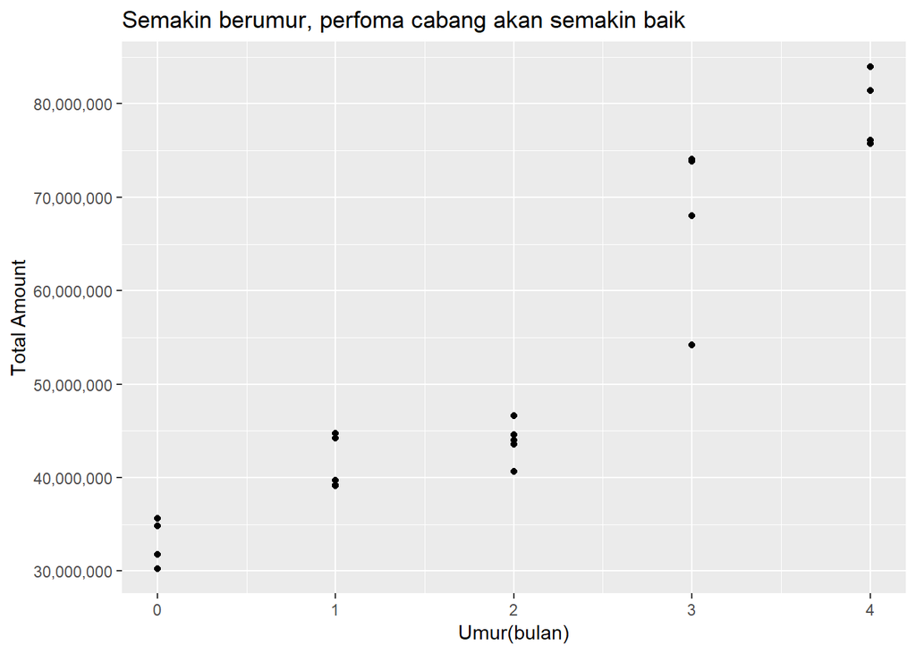

```r
library(ggplot2)
ggplot(df_loan_mei_umur, aes(x = umur, y = total_amount)) +
  geom_point() +
  scale_y_continuous(labels = scales::comma) +
  labs(title = "Semakin berumur, perfoma cabang akan semakin baik",
       x = "Umur(bulan)",
       y = "Total Amount")
```

#### Kesimpulan

Terlihat bahwa ada pola semakin tua cabang, maka performa nya semakin baik. Hal ini karena cabang tersebut masih berkembang sehingga belum sampai pada performa maksimal.

Akan tetapi pada masing - masing umur itu juga ada cabang yang performanya dibawah yang lain.

Selanjutnya akan dianalisis cabang yang performanya lebih rendah dari yang lain pada umur yang sama

### Mencari cabang yang perfoma rendah untuk setiap umur

Selanjutnya Untuk mencari cabang yang performanya rendah pada setiap kelompok umur, akan digunakan nilai `Quartile` dan `Inter Quartile Range` dari setiap umur. Dikatakan rendah jika performanya kurang dari **(Q1 - IQR)**. Untuk itu perlu dicari dulu nilai **Q1, Q3 dan IQR** untuk setiap umur dengan menggunakan data df_loan_mei_umur. Untuk membuat variabel ini, gunakan `group_by` dan `mutate` karena variabel ini akan digunakan lagi oleh semua data.

Setelah itu buat variabel baru **flag** yang akan berisi **‘rendah’** jika performanya **kurang** dari **(Q1 - IQR)** dan **‘baik’** untuk selain itu dan simpan hasilnya sebagai **df_loan_mei_flag**.

Lalu filter df_loan_mei_flag hanya untuk flag rendah, agar terlihat cabang mana saja yang masuk kelompok ini, dan ubah kolom numeric menjadi `comma` dengan fungsi `mutate_if`

Jangan lupa gunakan pipe **%>%** untuk menyambungkan fungsi.

```r
library(dplyr)
library(scales)
df_loan_mei_flag <- df_loan_mei_umur %>%
  group_by(umur) %>%
  mutate(Q1 = quantile(total_amount, 0.25),
       Q3 = quantile(total_amount, 0.75),
      IQR = (Q3-Q1)) %>%
  mutate(flag = ifelse(total_amount < (Q1 - IQR), 'rendah','baik'))

df_loan_mei_flag %>%
  filter(flag == 'rendah') %>%
  mutate_if(is.numeric, funs(comma))
```

```
## `mutate_if()` ignored the following grouping variables:
## Column `umur`
```

[output not shown]

```
## # A tibble: 2 x 8
## # Groups:   umur [2]
##   cabang pertama_cair  umur total_amount Q1        Q3        IQR      flag
##   <chr>  <chr>        <dbl> <chr>        <chr>     <chr>     <chr>    <chr>
## 1 AE     2020-02-03       3 54,200,000   64,580,0~ 73,900,0~ 9,320,0~ rend~
## 2 AL     2020-03-02       2 40,650,000   43,580,0~ 44,590,0~ 1,010,0~ rend~
```

### Buat Scatterplot lagi dan beri warna merah pada cabang yang rendah tadi

Untuk memperjelas bagaimana performa cabang yang rendah ini, plot lagi seperti sebelumnya. Sekarang menggunakan data yang baru, yakni **df_loan_mei_flag**. Lalu beri warna biru untuk cabang dengan flag ‘baik’ dan merah untuk yang ‘rendah’.

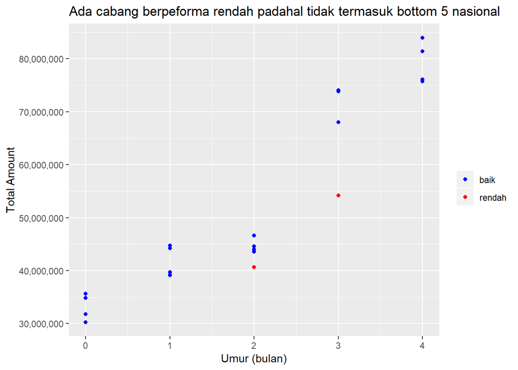

```r
library(ggplot2)

ggplot(df_loan_mei_flag, aes(x = umur, y = total_amount)) +
  geom_point(aes(color = flag)) +
  scale_color_manual(breaks = c("baik", "rendah"),
                     values=c("blue", "red")) +
  scale_y_continuous(labels = scales::comma) +
  labs(title = "Ada cabang berpeforma rendah padahal tidak termasuk bottom 5 nasional",
       color = "",
       x = "Umur (bulan)",
       y = "Total Amount")
```

### Lihat perbadingan performa cabang di umur yang sama

Selanjutnya akan dianalisis lebih lanjut kenapa cabang itu bisa performanya rendah di mei

Untuk kali ini akan dilihat hanya untuk yang umur **3 bulan** saja, dilihat detail performa pada bulan mei dengan mengihitung,

- jumlah hari pencairan dalam 1 bulan,
- jumlah agen yang aktif,
- total loan yang cair,
- rata - rata amount cair per loan.

dan ubah kolom numeric menjadi `comma` dengan fungsi `mutate_if`

Jangan lupa gunakan pipe **%>%** untuk menyambungkan fungsi.

```r
library(dplyr)
library(scales)
df_loan_mei_flag %>%
  filter(umur == 3) %>%
  inner_join(df_loan, by = 'cabang') %>%
  filter(tanggal_cair >= '2020-05-01', tanggal_cair <= '2020-05-31') %>%
  group_by(cabang, flag) %>%
  summarise(jumlah_hari = n_distinct(tanggal_cair),
            agen_aktif = n_distinct(agen),
            total_loan_cair = n_distinct(loan_id),
            avg_amount = mean(amount),
            total_amount = sum(amount)) %>%
  arrange(total_amount) %>%
  mutate_if(is.numeric, funs(comma))
```

```
## `mutate_if()` ignored the following grouping variables:
## Column `cabang`
```

```
## # A tibble: 4 x 7
## # Groups:   cabang [4]
##   cabang flag  jumlah_hari agen_aktif total_loan_cair avg_amount
##   <chr>  <chr> <chr>       <chr>      <chr>           <chr>
## 1 AE     rend~ 21          3          175             309,714
## 2 AF     baik  21          3          225             302,400
## 3 AH     baik  21          3          241             306,390
## 4 AG     baik  21          3          241             307,386
## # ... with 1 more variable: total_amount <chr>
```

### Lihat perbadingan performa agen pada cabang yang rendah

Dari hasil eksplorasi sebelumnya, terlihat bahwa yang berbeda jauh hanya **total_loan_cair** saja. Jumlah hari dan jumlah agen dalam 1 bulan sama semua.

Selanjutnya perlu dilihat bagaimana perbandingan nya per agent.

Untuk melanjutkan tadi, dilihat untuk yang umur **3 bulan** dan **flag nya** rendah dilihat detail performa pada bulan mei per agen dengan mengihitung,

- jumlah hari pencairan dalam 1 bulan,
- total loan yang cair,
- rata - rata amount cair per loan
- total amount cair

dan ubah kolom numeric menjadi `comma` dengan fungsi `mutate_if`

Jangan lupa gunakan pipe **%>%** untuk menyambungkan fungsi.

```r
library(dplyr)
library(scales)
df_loan_mei_flag %>%
  filter(umur == 3, flag == 'rendah') %>%
  inner_join(df_loan, by = 'cabang') %>%
  filter(tanggal_cair >= '2020-05-01', tanggal_cair <= '2020-05-31') %>%
  group_by(cabang, agen) %>%
  summarise(jumlah_hari = n_distinct(tanggal_cair),
            total_loan_cair = n_distinct(loan_id),
            avg_amount = mean(amount),
            total_amount = sum(amount)) %>%
  arrange(total_amount) %>%
  mutate_if(is.numeric, funs(comma))
```

```
## `mutate_if()` ignored the following grouping variables:
## Column `cabang`
```

```
## # A tibble: 3 x 6
## # Groups:   cabang [1]
##   cabang agen  jumlah_hari total_loan_cair avg_amount total_amount
##   <chr>  <chr> <chr>       <chr>           <chr>      <chr>
## 1 AE     AE-3  4           16              310,625    4,970,000
## 2 AE     AE-2  18          73              320,274    23,380,000
## 3 AE     AE-1  21          86              300,581    25,850,000
```

Dengan cara yang hampir sama, akan dilihat bagaimana performa masing-masing agen dari cabang AH tersebut. Hanya saja untuk ini bisa langsung pakai data df_loan lalu filter nama cabang nya saja.

```r
library(dplyr)
library(scales)
df_loan %>%
  filter(cabang == 'AH') %>%
  filter(tanggal_cair >= '2020-05-01', tanggal_cair <= '2020-05-31') %>%
  group_by(cabang, agen) %>%
  summarise(jumlah_hari = n_distinct(tanggal_cair),
            total_loan_cair = n_distinct(loan_id),
            avg_amount = mean(amount),
            total_amount = sum(amount)) %>%
  arrange(total_amount) %>%
  mutate_if(is.numeric, funs(comma))
```

```
## `mutate_if()` ignored the following grouping variables:
## Column `cabang`
```

```
## # A tibble: 3 x 6
## # Groups:   cabang [1]
##   cabang agen  jumlah_hari total_loan_cair avg_amount total_amount
##   <chr>  <chr> <chr>       <chr>           <chr>      <chr>
## 1 AH     AH-3  19          74              303,649    22,470,000
## 2 AH     AH-1  21          81              301,358    24,410,000
## 3 AH     AH-2  21          86              313,488    26,960,000
```

#### Kesimpulan

Berdasarkan analisis tersebut, dapat disimpulkan bahwa rendahnya performa dari cabang AE adalah karena salah satu agen yang melakukan pencairan hanya 4 hari dalam 1 bulan, padahal agen lain bisa aktif 21 hari.

Hal ini membuat total amount dari agen tersebut hanya 20% dibandingkan agen yang lainnya.

Sedangkan pada cabang AH, performanya sangat baik karena ketiga agen melakukan pencairan hampir / selalu setiap hari kerja. 2 orang full 21 hari 1 orang 19 hari. Sehingga performa nya terjaga dengan baik.

Perlu diperhatikan juga bahwa untuk membandingkan performa cabang itu sebaiknya di kelompokkan dulu berdasarkan karakteristik yang sama. Tidak langsung semua cabang dibandingkan tanpa mengetahui karakteristik nya.

Apalagi ketika dalam real world nanti cabang ini bisa terletak di berbeda wilayah (pulau misalnya) yang mempunyai kultur yang berbeda

Selanjutnya perlu dianalisis lebih lanjut kenapa ada agen yang hanya aktif beberapa hari saja dalam sebulan.

Untuk kedepannya setiap agen agar dipastikan untuk bisa aktif setiap hari nya, sehingga bisa menjaga performa cabang.

#### Certificate

[figure not shown]